# Huiswerk Cursus Statistiek & R

Alexander Hoogenboom

29-3-2021

```r
library(dplyr)
library(tidyverse)
library(readxl)
```

## Huiswerk week 2

De dataset komt van: https://equalitylaw.eui.eu/database/. Het bevat data over de jurisprudentie van het Hof van Justitie inzake discriminatieaanlegenheden heden van het ‘begin’ tot en met 2018 met betrekking tot een paar gronden. Als onderzoeksvraag ben ik benieuwd naar de verhouding man/vrouw als verzoekers (= mensen die een zaak aanbrengen) bij prejudiciële verwijzingen zaken die de grond ‘gender’ betreffen.

```r
discriminationData <- read_excel("discriminationdataset.xlsx")
view(discriminationData)
# Een aantal dingen vallen op. De kolomnamen zijn stom - spaties in plaats van underscores, en zelfs met (). De 'dates' zijn niet goed ingelezen. En er zijn twee overbodige rijen (een rij met uitleg en een rij met totalen). Allereerst heb ik geprobeerd de data in te lezen onder verwijzing dat er 'date' in staat. Dat ging fout - R liep praktisch vast toen deze probeerde van alle data een datum te maken: discriminationData <- read_excel("discriminationdataset.xlsx", col_types=c("date")) .

#Overbodige rijen verwijderen. Extra komma is nodig zodat voor R duidelijk is dat het om rijen gaat en niet kolommen. Deze instructies gevolgd: https://stackoverflow.com/questions/12328056/how-do-i-delete-rows-in-a-data-frame.
nrow(discriminationData)
```

```
## [1] 423
```

```r
discriminationData <- discriminationData[-c(1, 423),]

#De 'dates' zijn incorrect in gelezen: https://www.rdocumentation.org/packages/openxlsx/versions/4.1.4/topics/convertToDate.
discriminationData$JUDGEMENT <- openxlsx::convertToDate(discriminationData$JUDGEMENT, origin = "1900-01-01")
discriminationData$`DATE LODGED` <- openxlsx::convertToDate(discriminationData$'DATE LODGED', origin = "1900-01-01")
#De data die ik wil gebruiken zijn als integer ingelezen. Maar het gaat om factoren (0, 1 / false/true). Je moet verder wel een redelijk zieke geest zijn als je in je kolomnamen allemaal speciale karakters opneemt. Maar goed. Dit gevolgd: https://stackoverflow.com/questions/7531868/how-to-rename-a-single-column-in-a-data-frame.
names(discriminationData)
```

```
##  [1] "JUDGEMENT"
##  [2] "DATE LODGED"
##  [3] "CASE NO."
##  [4] "NAME"
##  [5] "FEMALE LITIGANT(S)"
##  [6] "MALE LITIGANT(S)"
##  [7] "PRELIM REF"
##  [8] "INFRINGEMENT"
##  [9] "OTHER"
## [10] "2000/78"
## [11] "2000/43"
## [12] "1975/117    (equal pay; rep by recast)"
## [13] "1976/207    (equal work; rep by recast)"
## [14] "2002/73 (amending 76/207; rep by recast)"
## [15] "1979/7        (social security)"
```

[output cut: 59 more lines]

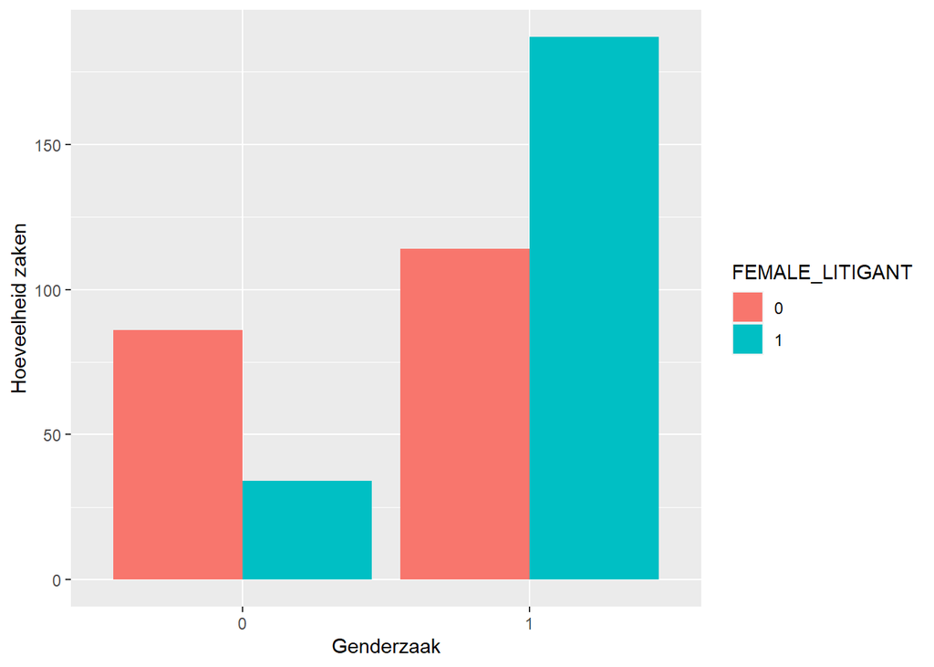

```r
colnames(discriminationData)[5] <- "FEMALE_LITIGANT"
view(discriminationData)
discriminationData <- mutate(discriminationData, FEMALE_LITIGANT = as.factor(FEMALE_LITIGANT))
discriminationData <- mutate(discriminationData, GENDER = as.factor(GENDER))
# Verschillende manieren: discriminationData <- mutate(discriminationData, FEMALE_LITIGANT = as.numeric(FEMALE_LITIGANT)). Deze werkt niet: discriminationData$FEMALE_LITIGANT <- as.logical(discriminationData$FEMALE_LITIGANT). Misschien toch mutate?

ggplot(discriminationData) + geom_bar(aes(x = GENDER, fill= FEMALE_LITIGANT), position = "dodge") + xlab("Genderzaak") + ylab("Hoeveelheid zaken")
```

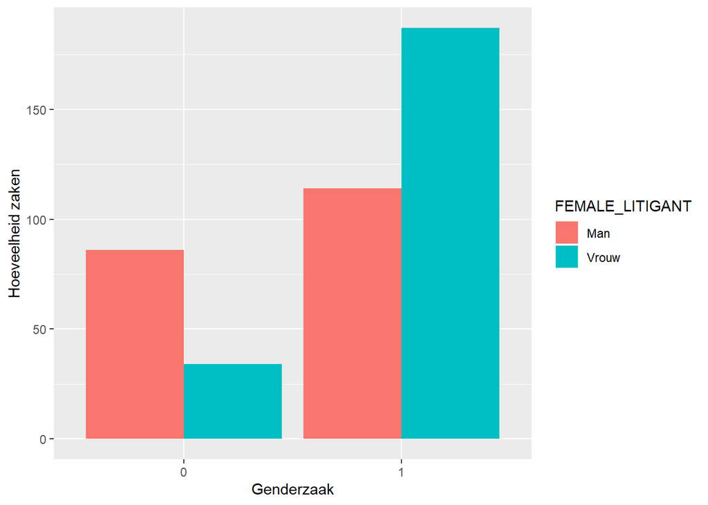

```r
# Wat het nog mooier zou maken: 0/1 hernoemen naar man, vrouw en de 0/1 naar overig en gender of iets dergelijks. Hieronder gedaan voor man/vrouw. Thanks to: https://www.edureka.co/community/35430/how-change-the-value-variable-using-programming-data-frame. Interessant dat hier mutate wordt overgeslagen... Eigenlijk eleganter.
discriminationData$FEMALE_LITIGANT <- as.character(discriminationData$FEMALE_LITIGANT)
discriminationData$FEMALE_LITIGANT[discriminationData$FEMALE_LITIGANT == "0"] <-"Man"
discriminationData$FEMALE_LITIGANT[discriminationData$FEMALE_LITIGANT == "1"] <-"Vrouw"
discriminationData <- mutate(discriminationData, FEMALE_LITIGANT = as.factor(FEMALE_LITIGANT))
ggplot(discriminationData) + geom_bar(aes(x = GENDER, fill= FEMALE_LITIGANT), position = "dodge") + xlab("Genderzaak") + ylab("Hoeveelheid zaken")
```

Interpretatie. Interessant is allereerst dat veruit de meeste zaken bij het Hof van Justitie over ‘gender’ gaan. Dat is makkelijk historisch verklaarbaar daar dit de eerste grond was die werd geïntroduceerd, o.a. vanwege een activistische houding van de HvJ rechters en een ‘onschuldige’ bepaling die dat Hof heel veel tanden heeft gegeven. De bredere non-discriminatiewetgeving is eigenlijk vooral sinds 2000. Daarnaast, zoals verwacht, klagen (klagen wordt hier in de juridische zin bedoeld) vrouwen vaker over genderdiscriminatie dan mannen. Interessant is wel dat voor de overige zaken mannen juist eerder klagen dan vrouwen. Probeersel aantal zaken te plotten in de tijd. Maar vereist nog redelijk wat data manipulatie. Code laat ik staan want handig voor later misschien. colnames(discriminationData)[7] <- “PRELIM_REF” discriminationData <- mutate(discriminationData, PRELIM_REF = as.numeric(PRELIM_REF)) ggplot(discriminationData) +geom_line(aes(x = JUDGEMENT, y = PRELIM_REF, colour = “PRELIM_REF”))